Derek Ruthardt

# INN Hotels Project

## Context

A significant number of hotel bookings are called-off due to cancellations or no-shows. The typical reasons for cancellations include change of plans, scheduling conflicts, etc. This is often made easier by the option to do so free of charge or preferably at a low cost which is beneficial to hotel guests but it is a less desirable and possibly revenue-diminishing factor for hotels to deal with. Such losses are particularly high on last-minute cancellations.

The new technologies involving online booking channels have dramatically changed customers’ booking possibilities and behavior. This adds a further dimension to the challenge of how hotels handle cancellations, which are no longer limited to traditional booking and guest characteristics.

The cancellation of bookings impact a hotel on various fronts:

- Loss of resources (revenue) when the hotel cannot resell the room.
- Additional costs of distribution channels by increasing commissions or paying for publicity to help sell these rooms.
- Lowering prices last minute, so the hotel can resell a room, resulting in reducing the profit margin.
- Human resources to make arrangements for the guests.

## Objective

The increasing number of cancellations calls for a Machine Learning based solution that can help in predicting which booking is likely to be canceled. INN Hotels Group has a chain of hotels in Portugal, they are facing problems with the high number of booking cancellations and have reached out to your firm for data-driven solutions. You as a data scientist have to analyze the data provided to find which factors have a high influence on booking cancellations, build a predictive model that can predict which booking is going to be canceled in advance, and help in formulating profitable policies for cancellations and refunds.

## Data Description

The data contains the different attributes of customers' booking details. The detailed data dictionary is given below.

**Data Dictionary**

- Booking_ID: unique identifier of each booking
- no_of_adults: Number of adults
- no_of_children: Number of Children
- no_of_weekend_nights: Number of weekend nights (Saturday or Sunday) the guest stayed or booked to stay at the hotel
- no_of_week_nights: Number of week nights (Monday to Friday) the guest stayed or booked to stay at the hotel
- type_of_meal_plan: Type of meal plan booked by the customer:
  - Not Selected – No meal plan selected
  - Meal Plan 1 – Breakfast
  - Meal Plan 2 – Half board (breakfast and one other meal)
  - Meal Plan 3 – Full board (breakfast, lunch, and dinner)
- required_car_parking_space: Does the customer require a car parking space? (0 - No, 1- Yes)
- room_type_reserved: Type of room reserved by the customer. The values are ciphered (encoded) by INN Hotels.
- lead_time: Number of days between the date of booking and the arrival date
- arrival_year: Year of arrival date
- arrival_month: Month of arrival date
- arrival_date: Date of the month
- market_segment_type: Market segment designation.
- repeated_guest: Is the customer a repeated guest? (0 - No, 1- Yes)
- no_of_previous_cancellations: Number of previous bookings that were canceled by the customer prior to the current booking
- no_of_previous_bookings_not_canceled: Number of previous bookings not canceled by the customer prior to the current booking
- avg_price_per_room: Average price per day of the reservation; prices of the rooms are dynamic. (in euros)
- no_of_special_requests: Total number of special requests made by the customer (e.g. high floor, view from the room, etc)
- booking_status: Flag indicating if the booking was canceled or not.

## Importing necessary libraries and data

```python
# Libraries to help with reading and manipulating data
import pandas as pd
import numpy as np

# libaries to help with data visualization
import matplotlib.pyplot as plt
import seaborn as sns

# Library to split data
from sklearn.model_selection import train_test_split


# To build linear model for statistical analysis and prediction
import statsmodels.stats.api as sms
from statsmodels.stats.outliers_influence import variance_inflation_factor
import statsmodels.api as sm
from statsmodels.tools.tools import add_constant

# To get diferent metric scores
from sklearn import metrics
from sklearn.metrics import accuracy_score, roc_curve, confusion_matrix, roc_auc_score
```

```python
from google.colab import drive
drive.mount('/content/drive')
```

Loading the dataset

```python
data_hotel = pd.read_csv("/content/drive/MyDrive/4 - Logistic Regression/INNHotelsGroup.csv")
```

```python
#Make a copy of the dataset
df = data_hotel.copy()
```

**Note**: *After running the above cell, kindly restart the notebook kernel and run all cells sequentially from the start again.*

## Data Overview

- Observations
- Sanity checks

View the first and last 5 rows of the dataset

```python
df.head()
```

|  | Booking_ID | no_of_adults | no_of_children | no_of_weekend_nights | no_of_week_nights | type_of_meal_plan | required_car_parking_space | room_type_reserved | lead_time | arrival_year | arrival_month | arrival_date | market_segment_type | repeated_guest | no_of_previous_cancellations | no_of_previous_bookings_not_canceled | avg_price_per_room | no_of_special_requests | booking_status |
| --- | --- | --- | --- | --- | --- | --- | --- | --- | --- | --- | --- | --- | --- | --- | --- | --- | --- | --- | --- |
| 0 | INN00001 | 2 | 0 | 1 | 2 | Meal Plan 1 | 0 | Room_Type 1 | 224 | 2017 | 10 | 2 | Offline | 0 | 0 | 0 | 65.00 | 0 | Not_Canceled |
| 1 | INN00002 | 2 | 0 | 2 | 3 | Not Selected | 0 | Room_Type 1 | 5 | 2018 | 11 | 6 | Online | 0 | 0 | 0 | 106.68 | 1 | Not_Canceled |
| 2 | INN00003 | 1 | 0 | 2 | 1 | Meal Plan 1 | 0 | Room_Type 1 | 1 | 2018 | 2 | 28 | Online | 0 | 0 | 0 | 60.00 | 0 | Canceled |
| 3 | INN00004 | 2 | 0 | 0 | 2 | Meal Plan 1 | 0 | Room_Type 1 | 211 | 2018 | 5 | 20 | Online | 0 | 0 | 0 | 100.00 | 0 | Canceled |
| 4 | INN00005 | 2 | 0 | 1 | 1 | Not Selected | 0 | Room_Type 1 | 48 | 2018 | 4 | 11 | Online | 0 | 0 | 0 | 94.50 | 0 | Canceled |

```python
df.tail()
```

|  | Booking_ID | no_of_adults | no_of_children | no_of_weekend_nights | no_of_week_nights | type_of_meal_plan | required_car_parking_space | room_type_reserved | lead_time | arrival_year | arrival_month | arrival_date | market_segment_type | repeated_guest | no_of_previous_cancellations | no_of_previous_bookings_not_canceled | avg_price_per_room | no_of_special_requests | booking_status |
| --- | --- | --- | --- | --- | --- | --- | --- | --- | --- | --- | --- | --- | --- | --- | --- | --- | --- | --- | --- |
| 36270 | INN36271 | 3 | 0 | 2 | 6 | Meal Plan 1 | 0 | Room_Type 4 | 85 | 2018 | 8 | 3 | Online | 0 | 0 | 0 | 167.80 | 1 | Not_Canceled |
| 36271 | INN36272 | 2 | 0 | 1 | 3 | Meal Plan 1 | 0 | Room_Type 1 | 228 | 2018 | 10 | 17 | Online | 0 | 0 | 0 | 90.95 | 2 | Canceled |
| 36272 | INN36273 | 2 | 0 | 2 | 6 | Meal Plan 1 | 0 | Room_Type 1 | 148 | 2018 | 7 | 1 | Online | 0 | 0 | 0 | 98.39 | 2 | Not_Canceled |
| 36273 | INN36274 | 2 | 0 | 0 | 3 | Not Selected | 0 | Room_Type 1 | 63 | 2018 | 4 | 21 | Online | 0 | 0 | 0 | 94.50 | 0 | Canceled |
| 36274 | INN36275 | 2 | 0 | 1 | 2 | Meal Plan 1 | 0 | Room_Type 1 | 207 | 2018 | 12 | 30 | Offline | 0 | 0 | 0 | 161.67 | 0 | Not_Canceled |

Check the shape of the dataset

```python
df.shape
```

```
(36275, 19)
```

- There are 36275 observations and 19 columns in the dataset.

Check for null values in the dataset

```python
#Check for null values in data
df.isnull().values.any()
```

```
False
```

There are no missing values in the data

Check for duplicates in the dataset.

```python
#Check for duplicates in the data
df.duplicated().values.any()
```

```
False
```

There are no duplicates in the dataset

```python
#Check the datatypes in the data
df.info()
```

```
<class 'pandas.core.frame.DataFrame'>
RangeIndex: 36275 entries, 0 to 36274
Data columns (total 19 columns):
 #   Column                                Non-Null Count  Dtype
---  ------                                --------------  -----
 0   Booking_ID                            36275 non-null  object
 1   no_of_adults                          36275 non-null  int64
 2   no_of_children                        36275 non-null  int64
 3   no_of_weekend_nights                  36275 non-null  int64
 4   no_of_week_nights                     36275 non-null  int64
 5   type_of_meal_plan                     36275 non-null  object
 6   required_car_parking_space            36275 non-null  int64
 7   room_type_reserved                    36275 non-null  object
 8   lead_time                             36275 non-null  int64
 9   arrival_year                          36275 non-null  int64
 10  arrival_month                         36275 non-null  int64
 11  arrival_date                          36275 non-null  int64
 12  market_segment_type                   36275 non-null  object
 13  repeated_guest                        36275 non-null  int64
 14  no_of_previous_cancellations          36275 non-null  int64
 15  no_of_previous_bookings_not_canceled  36275 non-null  int64
 16  avg_price_per_room                    36275 non-null  float64
 17  no_of_special_requests                36275 non-null  int64
 18  booking_status                        36275 non-null  object
dtypes: float64(1), int64(13), object(5)
memory usage: 5.3+ MB
```

We have 19 columns of data, 1 float, 13 integer, and 5 object. There appears to be no missing data.

We can drop the booking id since it will not help us for analysis.

```python
#Drop column booking id from df
df = df.drop('Booking_ID', axis=1)
```

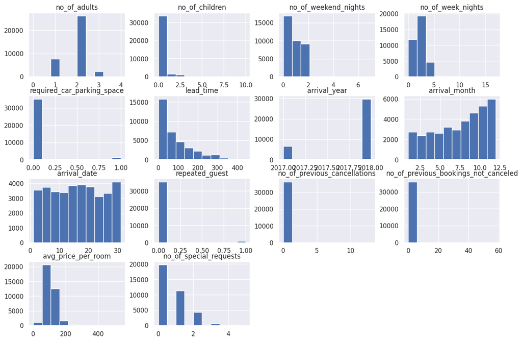

```python
sns.set_style("darkgrid")
df.hist(figsize=(15, 10))
plt.show()
```

## Exploratory Data Analysis (EDA)

- EDA is an important part of any project involving data.
- It is important to investigate and understand the data better before building a model with it.
- A few questions have been mentioned below which will help you approach the analysis in the right manner and generate insights from the data.
- A thorough analysis of the data, in addition to the questions mentioned below, should be done.

**Leading Questions**:

1. What are the busiest months in the hotel?
2. Which market segment do most of the guests come from?
3. Hotel rates are dynamic and change according to demand and customer demographics. What are the differences in room prices in different market segments?
4. What percentage of bookings are canceled?
5. Repeating guests are the guests who stay in the hotel often and are important to brand equity. What percentage of repeating guests cancel?
6. Many guests have special requirements when booking a hotel room. Do these requirements affect booking cancellation?

Check the statistical summary for the dataset

```python
#df summary
df.describe().T
```

|  | count | mean | std | min | 25% | 50% | 75% | max |
| --- | --- | --- | --- | --- | --- | --- | --- | --- |
| no_of_adults | 36275.0 | 1.844962 | 0.518715 | 0.0 | 2.0 | 2.00 | 2.0 | 4.0 |
| no_of_children | 36275.0 | 0.105279 | 0.402648 | 0.0 | 0.0 | 0.00 | 0.0 | 10.0 |
| no_of_weekend_nights | 36275.0 | 0.810724 | 0.870644 | 0.0 | 0.0 | 1.00 | 2.0 | 7.0 |
| no_of_week_nights | 36275.0 | 2.204300 | 1.410905 | 0.0 | 1.0 | 2.00 | 3.0 | 17.0 |
| required_car_parking_space | 36275.0 | 0.030986 | 0.173281 | 0.0 | 0.0 | 0.00 | 0.0 | 1.0 |
| lead_time | 36275.0 | 85.232557 | 85.930817 | 0.0 | 17.0 | 57.00 | 126.0 | 443.0 |
| arrival_year | 36275.0 | 2017.820427 | 0.383836 | 2017.0 | 2018.0 | 2018.00 | 2018.0 | 2018.0 |
| arrival_month | 36275.0 | 7.423653 | 3.069894 | 1.0 | 5.0 | 8.00 | 10.0 | 12.0 |
| arrival_date | 36275.0 | 15.596995 | 8.740447 | 1.0 | 8.0 | 16.00 | 23.0 | 31.0 |
| repeated_guest | 36275.0 | 0.025637 | 0.158053 | 0.0 | 0.0 | 0.00 | 0.0 | 1.0 |
| no_of_previous_cancellations | 36275.0 | 0.023349 | 0.368331 | 0.0 | 0.0 | 0.00 | 0.0 | 13.0 |
| no_of_previous_bookings_not_canceled | 36275.0 | 0.153411 | 1.754171 | 0.0 | 0.0 | 0.00 | 0.0 | 58.0 |
| avg_price_per_room | 36275.0 | 103.423539 | 35.089424 | 0.0 | 80.3 | 99.45 | 120.0 | 540.0 |
| no_of_special_requests | 36275.0 | 0.619655 | 0.786236 | 0.0 | 0.0 | 0.00 | 1.0 | 5.0 |

The average number of adults is slightly under 2. The most common number of adults for a booking is 2

Most bookings do not include children which is making the average value very low.

Most people were not repeat customers.

There are many colums with averages near zero (required parking spaces, repeated guest, no_of_previous cancellations, no_of_previous_bookings_not_cancelled, and no_of_special_requests.

### Leading Questions

Q1. What are the busiest months in the hotel?

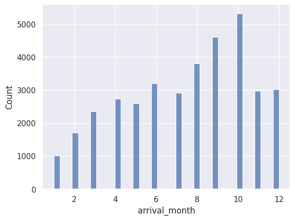

```python
#histogram for arrival month
sns.histplot(df['arrival_month'])
```

A1. The busiest months are October and September, followed by August and June. October is the busiest month.

Q2. Which market segment do most of the guests come from?

Create a histogram of market segment type by percentage

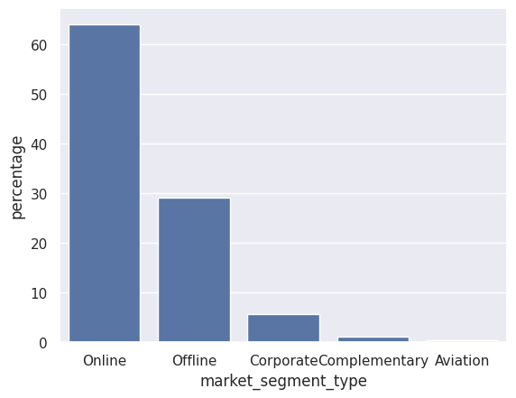

```python
# Calculate the percentage for each market segment
percentage = df['market_segment_type'].value_counts(normalize=True) * 100

# Create a new DataFrame with the market segment and its corresponding percentage
df_percentage = pd.DataFrame({'market_segment_type': percentage.index, 'percentage': percentage.values})

# Plot the histogram using the df_percentage DataFrame which contains the 'percentage' column
sns.barplot(x='market_segment_type', y='percentage', data=df_percentage)
```

A2. Over 60% of guests come from the online market segment. The next largest segment is offline which represents almost 30% of bookings. The online market could provide a large opportunity to decrease cancellations.

Q3. Hotel rates are dynamic and change according to demand and customer demographics. What are the differences in room prices in different market segments?

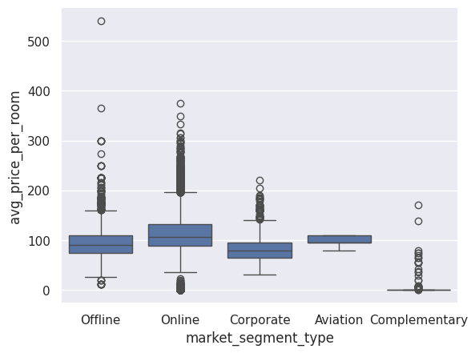

```python
# Display room prices in different market segemnts
sns.boxplot(x='market_segment_type', y='avg_price_per_room', data=df)
```

```python
# Calculate the difference in room price by market segment
df.groupby('market_segment_type')['avg_price_per_room'].mean().sort_values(ascending=False)
```

| market_segment_type | avg_price_per_room |
| --- | --- |
| Online | 112.256855 |
| Aviation | 100.704000 |
| Offline | 91.632679 |
| Corporate | 82.911740 |
| Complementary | 3.141765 |

**dtype:** float64

A3.

The online market segemnt has the highest average room price of 112, followed by Aviation at 100.7, Offline at 91.6, and Corporate at about 83.

Online booking price average is about 20 euros higher than the offline booking price.

Q4. What percentage of bookings are canceled?

```python
# Find the percentage of rooms cancelled
df['booking_status'].value_counts(normalize=True) * 100
```

| booking_status | proportion |
| --- | --- |
| Not_Canceled | 67.236389 |
| Canceled | 32.763611 |

**dtype:** float64

A4. 32.7% of rooms were cancelled.

Q5. Repeating guests are the guests who stay in the hotel often and are important to brand equity. What percentage of repeating guests cancel?

```python
# Find the percentage of repeat customers that cancel
df[df['repeated_guest'] == 1]['booking_status'].value_counts(normalize=True) * 100
```

| booking_status | proportion |
| --- | --- |
| Not_Canceled | 98.27957 |
| Canceled | 1.72043 |

**dtype:** float64

A5. Only 1.7 % of repeat customers cancelled. This is a marketable difference compared to the average cancellation rate of 32.7 %. This could indicate that repeat customers have a strong loyalty to keep their reservations.

Q6. Many guests have special requirements when booking a hotel room. Do these requirements affect booking cancellation?

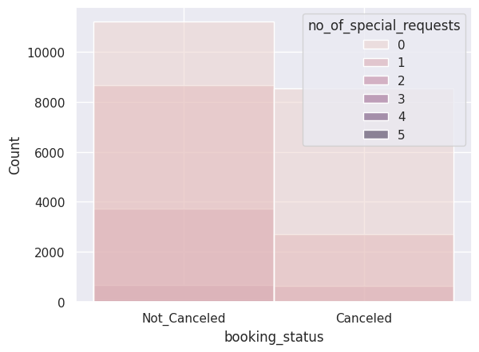

```python
# Histogram of booking status with hue of number of special requests > 0
sns.histplot(x='booking_status', hue='no_of_special_requests', data=df)
```

Finding the percentage of those with special requests that cancelled.

```python
# Find the percentage of guest with special requirements that cancel
df[df['no_of_special_requests'] > 0]['booking_status'].value_counts(normalize=True) * 100
```

| booking_status | proportion |
| --- | --- |
| Not_Canceled | 79.755122 |
| Canceled | 20.244878 |

**dtype:** float64

A6. Guests with special requests cancelled 20% of the time. This is less than the average cancellation rate of 32.7%. This indicates that offering special requests to customers could reduce cancellations.

### Univariate Analysis

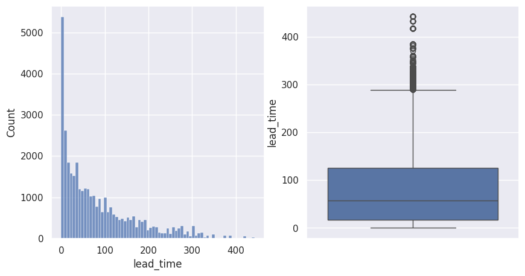

```python
#histogram and boxplot for lead time
fig, ax = plt.subplots(1, 2, figsize=(10, 5))
sns.histplot(df['lead_time'], ax=ax[0])
sns.boxplot(df['lead_time'], ax=ax[1])
```

Lead time is skewed to the right due to some outliers with large lead time. Most lead times are less than 100 days.

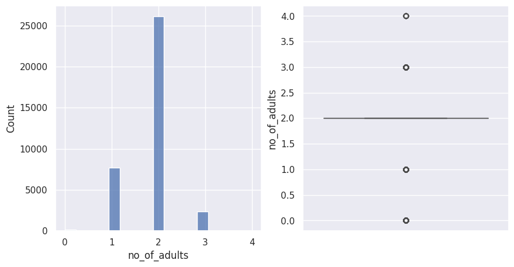

```python
#histogram and boxplot for number of adults
fig, ax = plt.subplots(1, 2, figsize=(10, 5))
sns.histplot(df['no_of_adults'], ax=ax[0])
sns.boxplot(df['no_of_adults'], ax=ax[1])
```

Most bookings are represented by 2 adults

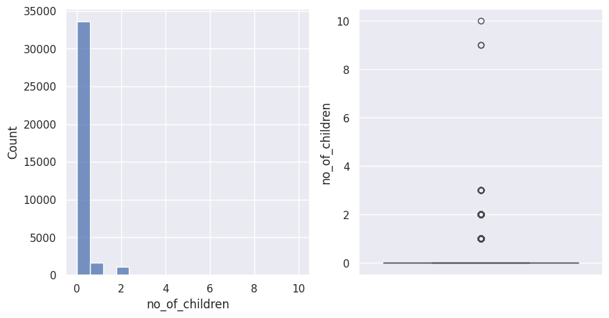

```python
#histogram and boxplot for number of children
fig, ax = plt.subplots(1, 2, figsize=(10, 5))
sns.histplot(df['no_of_children'], ax=ax[0])
sns.boxplot(df['no_of_children'], ax=ax[1])
```

Most trips are booked without children

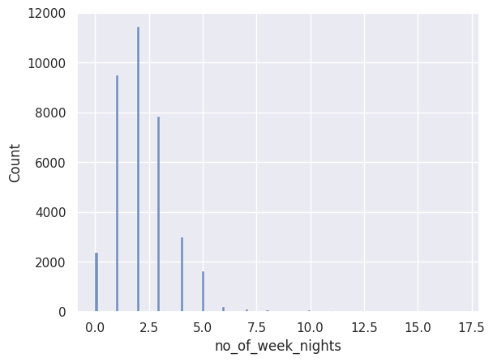

```python
#histogram for no_of_week_nights
sns.histplot(df['no_of_week_nights'])
```

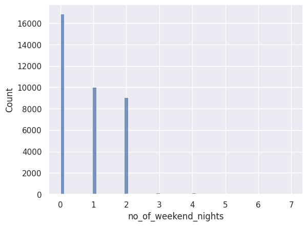

```python
#histogram for no_of_weekend_nights
sns.histplot(df['no_of_weekend_nights'])
```

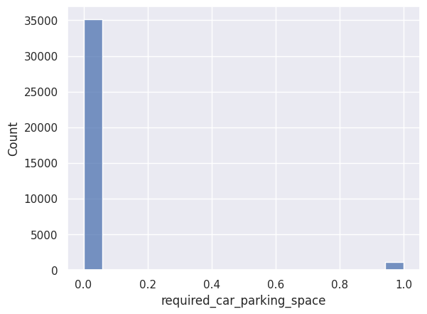

```python
#histogram for required parking space
sns.histplot(df['required_car_parking_space'])
```

Almost all trips did not include a required parking space.

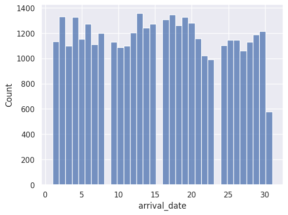

```python
#histogram of arrival date
sns.histplot(df['arrival_date'])
```

Arrival days are fairly evenly distributed.

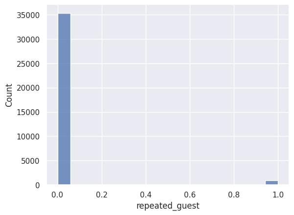

```python
#histogram of repeated guest
sns.histplot(df['repeated_guest'])
```

Almost all the guests are not repeat customers.

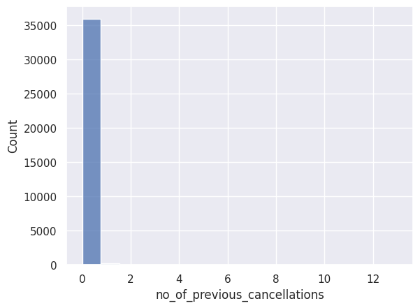

```python
#histogram of no of cancellations
sns.histplot(df['no_of_previous_cancellations'])
```

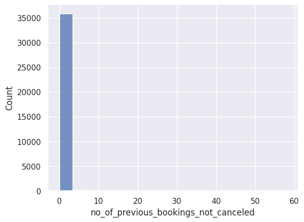

```python
#histogram of no of previous bookings not cancelled
sns.histplot(df['no_of_previous_bookings_not_canceled'])
```

The number of previous cancellations and bookings not cancelled are both almost all zero; this could be a result of almost all geusts being new customers.

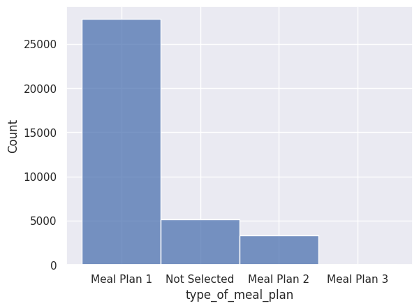

```python
#histogram for meal plan
sns.histplot(df['type_of_meal_plan'])
```

Meal plan 1 is by far the most selected.

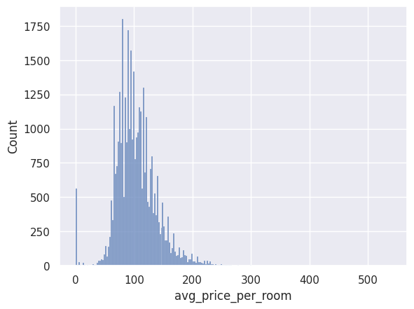

```python
#histogram for avg price per room
sns.histplot(df['avg_price_per_room'])
```

Average price per room is close to normally distributed with some skew to the right.

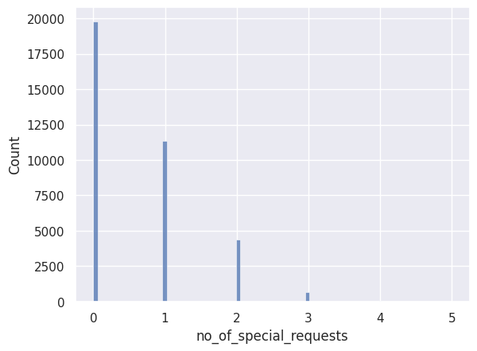

```python
#histogram for special requests
sns.histplot(df['no_of_special_requests'])
```

Most trips did not include a special request.

```python
#Encode 1 for cancelled and 0 for not cancelled in booking status
df['booking_status'] = df['booking_status'].apply(lambda x: 1 if x == 'Canceled' else 0)
```

### Bivariate Analysis

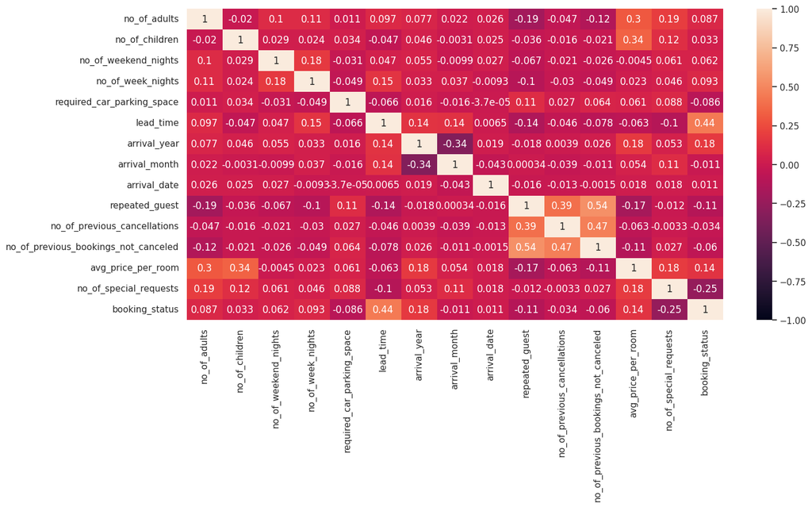

```python
#create a new df with all numerical variables
df_num = df.select_dtypes(include=['int64', 'float64'])
#heatmap for df_num
plt.figure(figsize=(15, 7))
sns.heatmap(df_num.corr(), annot=True, vmin=-1, vmax=1)
plt.show()
```

Lead time and booking status cancelled have the most positive correlation. Number of special requests has a negative correlation with cancellations. Number of children and number of adults both have a positive correlation with avg room price, as we would expect.

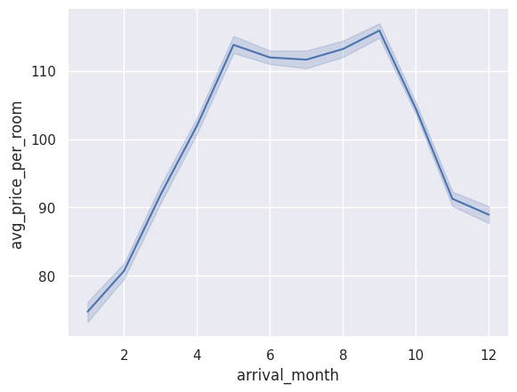

```python
#Line plot of arrival month and avg price per room
sns.lineplot(x='arrival_month', y='avg_price_per_room', data=df)
```

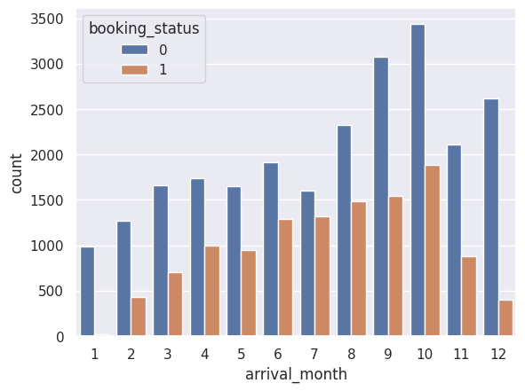

```python
#Chart booking status by month
sns.countplot(x='arrival_month', hue='booking_status', data=df)
```

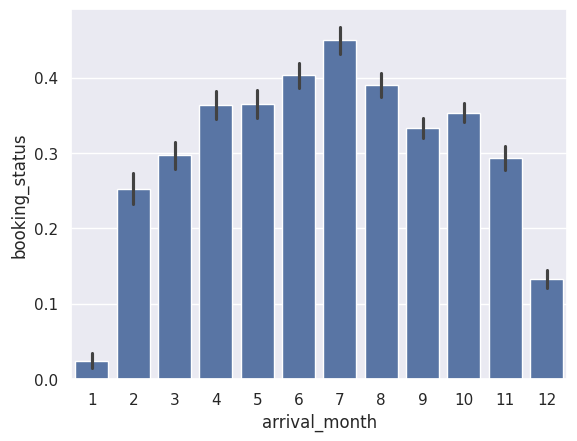

```python
#Cancellation rate by month
sns.barplot(x='arrival_month', y='booking_status', data=df)
```

Cancellation rate is highest in June, July and August. The cancellation rate for July is the highest (45%)

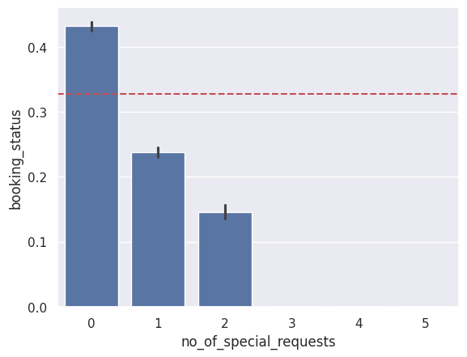

```python
#Cancellation rate by number of special requests
sns.barplot(x='no_of_special_requests', y='booking_status', data=df)
#Show average cancellation on the barplot
sns.set(style="whitegrid")
plt.axhline(y=df['booking_status'].mean(), color='r', linestyle='--')
```

Cancellation rate for those with special requests is lower than the average cancellation rate. There is a trend as special requests go up, cancellations decrease.

Customers with zero special requests cancel over 40% of the time.

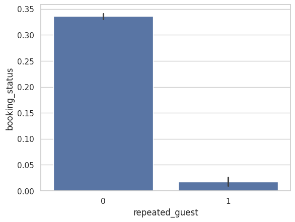

```python
#Cancellation rate by repeat customer
sns.barplot(x='repeated_guest', y='booking_status', data=df)
```

Repeat customers have a drastically lower cancellation rate compared to the new customers.

## Data Preprocessing

- Missing value treatment (if needed)
- Feature engineering (if needed)
- Outlier detection and treatment (if needed)
- Preparing data for modeling
- Any other preprocessing steps (if needed)

```python
#Check for missing data in df
df.isnull().sum()
```

|  | 0 |
| --- | --- |
| no_of_adults | 0 |
| no_of_children | 0 |
| no_of_weekend_nights | 0 |
| no_of_week_nights | 0 |
| type_of_meal_plan | 0 |
| required_car_parking_space | 0 |
| room_type_reserved | 0 |
| lead_time | 0 |
| arrival_year | 0 |
| arrival_month | 0 |
| arrival_date | 0 |
| market_segment_type | 0 |
| repeated_guest | 0 |
| no_of_previous_cancellations | 0 |
| no_of_previous_bookings_not_canceled | 0 |
| avg_price_per_room | 0 |
| no_of_special_requests | 0 |
| booking_status | 0 |

**dtype:** int64

There is no missing data to be treated.

We have seen some outliers in the data, but will keep those data points for analysis

```python
#Check the distribution of the target variable booking status
df['booking_status'].value_counts()
```

| booking_status | count |
| --- | --- |
| 0 | 24390 |
| 1 | 11885 |

**dtype:** int64

```python
#Show as a proportion
df['booking_status'].value_counts(normalize=True)
```

| booking_status | proportion |
| --- | --- |
| 0 | 0.672364 |
| 1 | 0.327636 |

**dtype:** float64

Our target variable will be cancelled bookings. There are 11,885 observations of cancelled bookings. This represents 32.7% of our data as cancellations.

### Splitting the data into train and test

```python
X = df.drop(["booking_status"], axis=1)
Y = df["booking_status"]

# adding a contstant to X variable
X = add_constant(X)

# creating dummies
X = pd.get_dummies(X, drop_first=True)


# Splitting data in train and test sets
X_train, X_test, y_train, y_test = train_test_split(
    X, Y, test_size=0.30, random_state=1, stratify=Y
)
```

```python
# fitting the model on training set
logit = sm.Logit(y_train, X_train.astype(float))
lg = logit.fit()
```

```python
# let's print the logistic regression summary
print(lg.summary())
```

```
                           Logit Regression Results
==============================================================================
Dep. Variable:         booking_status   No. Observations:                25392
Model:                          Logit   Df Residuals:                    25364
Method:                           MLE   Df Model:                           27
Date:                Thu, 26 Sep 2024   Pseudo R-squ.:                  0.3322
Time:                        23:19:17   Log-Likelihood:                -10724.
converged:                      False   LL-Null:                       -16060.
Covariance Type:            nonrobust   LLR p-value:                     0.000
========================================================================================================
                                           coef    std err          z      P>|z|      [0.025      0.975]
--------------------------------------------------------------------------------------------------------
const                                 -886.9563    121.332     -7.310      0.000   -1124.762    -649.150
no_of_adults                             0.0333      0.038      0.883      0.377      -0.041       0.107
no_of_children                           0.0833      0.061      1.371      0.170      -0.036       0.202
no_of_weekend_nights                     0.1461      0.020      7.368      0.000       0.107       0.185
no_of_week_nights                        0.0354      0.012      2.881      0.004       0.011       0.059
required_car_parking_space              -1.6146      0.137    -11.769      0.000      -1.883      -1.346
lead_time                                0.0158      0.000     58.946      0.000       0.015       0.016
arrival_year                             0.4382      0.060      7.288      0.000       0.320       0.556
arrival_month                           -0.0475      0.006     -7.315      0.000      -0.060      -0.035
arrival_date                             0.0030      0.002      1.528      0.127      -0.001       0.007
repeated_guest                          -1.9186      0.767     -2.502      0.012      -3.421      -0.416
no_of_previous_cancellations             0.3476      0.102      3.413      0.001       0.148       0.547
no_of_previous_bookings_not_canceled    -1.3821      0.906     -1.526      0.127      -3.157       0.393
avg_price_per_room                       0.0184      0.001     24.903      0.000       0.017       0.020
no_of_special_requests                  -1.4904      0.030    -48.963      0.000      -1.550      -1.431
type_of_meal_plan_Meal Plan 2            0.1746      0.067      2.607      0.009       0.043       0.306
type_of_meal_plan_Meal Plan 3           10.1525    107.969      0.094      0.925    -201.464     221.769
type_of_meal_plan_Not Selected           0.1995      0.053      3.741      0.000       0.095       0.304
room_type_reserved_Room_Type 2          -0.4172      0.133     -3.129      0.002      -0.679      -0.156
room_type_reserved_Room_Type 3           1.1881      1.891      0.628      0.530      -2.518       4.895
room_type_reserved_Room_Type 4          -0.2679      0.053     -5.019      0.000      -0.373      -0.163
room_type_reserved_Room_Type 5          -0.6822      0.215     -3.173      0.002      -1.104      -0.261
room_type_reserved_Room_Type 6          -0.8460      0.153     -5.534      0.000      -1.146      -0.546
room_type_reserved_Room_Type 7          -1.3601      0.298     -4.566      0.000      -1.944      -0.776
market_segment_type_Complementary      -24.5570   2.24e+04     -0.001      0.999   -4.39e+04    4.39e+04
market_segment_type_Corporate           -0.8514      0.276     -3.087      0.002      -1.392      -0.311
market_segment_type_Offline             -1.7645      0.264     -6.688      0.000      -2.282      -1.247
market_segment_type_Online               0.0070      0.261      0.027      0.979      -0.504       0.518
========================================================================================================
```

The coefficients of the logistic regression model are in terms of log(odd). P>|z|: The interpretation of p-values is similar to that in Linear Regression.

Check the model performance

```python
# predicting on training set
# default threshold is 0.5, if predicted probability is greater than 0.5 the observation will be classified as 1
pred_train = lg.predict(X_train.astype(float)) # Ensure X_train is of type float
pred_train = np.where(pred_train > 0.5, 1, 0)
```

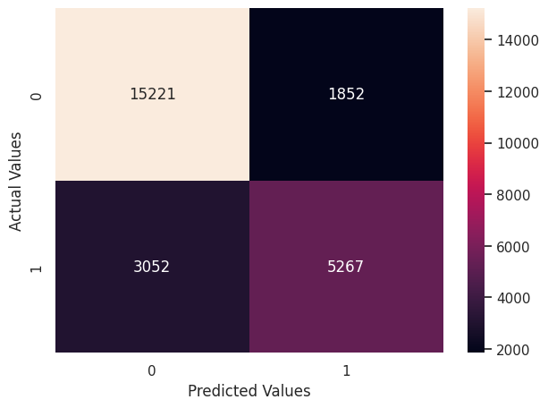

```python
#Confusion matrix on training set
cm = confusion_matrix(y_train, pred_train)
plt.figure(figsize=(7, 5))
sns.heatmap(cm, annot=True, fmt="g")
plt.xlabel("Predicted Values")
plt.ylabel("Actual Values")
plt.show()
```

The confusion matrix

True Positives (TP): A customer cancels and the model predicted customer to cancel.

True Negatives (TN): A customer doesn't cancel and the model predicted customer doesn't cancel.

False Positives (FP): The model predicted customer cancels but the customer doesn't cancel.

False Negatives (FN): The model predicted customer doesn't cancel but the customer cancels.

Checking Accuracy

```python
print("Accuracy on training set : ", accuracy_score(y_train, pred_train))
```

```
Accuracy on training set :  0.8068683049779458
```

The model seems to be performing well with an accuracy of 80.6%

## Checking Multicollinearity

- In order to make statistical inferences from a logistic regression model, it is important to ensure that there is no multicollinearity present in the data.

```python
# let's check the VIF of the predictors
# Convert all columns in X_train to numeric types
X_train = X_train.apply(pd.to_numeric, errors='coerce')

# Convert X_train to float values
X_train = X_train.astype(float)

vif_series = pd.Series(
    [variance_inflation_factor(X_train.values, i) for i in range(X_train.shape[1])],
    index=X_train.columns,
    dtype=float,
)
print("VIF values: \n\n{}\n".format(vif_series))
```

```
VIF values:

const                                   3.959545e+07
no_of_adults                            1.345059e+00
no_of_children                          2.007213e+00
no_of_weekend_nights                    1.067255e+00
no_of_week_nights                       1.094373e+00
required_car_parking_space              1.034943e+00
lead_time                               1.401920e+00
arrival_year                            1.433261e+00
arrival_month                           1.277398e+00
arrival_date                            1.007629e+00
repeated_guest                          1.750194e+00
no_of_previous_cancellations            1.322011e+00
no_of_previous_bookings_not_canceled    1.570863e+00
avg_price_per_room                      2.032631e+00
no_of_special_requests                  1.247233e+00
type_of_meal_plan_Meal Plan 2           1.261818e+00
type_of_meal_plan_Meal Plan 3           1.007964e+00
type_of_meal_plan_Not Selected          1.279209e+00
room_type_reserved_Room_Type 2          1.094581e+00
room_type_reserved_Room_Type 3          1.003898e+00
room_type_reserved_Room_Type 4          1.355784e+00
room_type_reserved_Room_Type 5          1.030903e+00
room_type_reserved_Room_Type 6          1.990106e+00
room_type_reserved_Room_Type 7          1.092074e+00
market_segment_type_Complementary       4.350047e+00
market_segment_type_Corporate           1.663442e+01
market_segment_type_Offline             6.251301e+01
market_segment_type_Online              6.947183e+01
dtype: float64
```

We will remove the highest VIF and retrain the model

```python
#Remove market segment type online and create a new training set
X_train2 = X_train.drop(["market_segment_type_Online"], axis=1)
```

```python
#Re train with X_train2
logit2 = sm.Logit(y_train, X_train2.astype(float))
lg2 = logit2.fit()
```

```python
#print the new lg2 summary
print(lg2.summary())
```

```
                           Logit Regression Results
==============================================================================
Dep. Variable:         booking_status   No. Observations:                25392
Model:                          Logit   Df Residuals:                    25365
Method:                           MLE   Df Model:                           26
Date:                Thu, 26 Sep 2024   Pseudo R-squ.:                  0.3322
Time:                        23:19:19   Log-Likelihood:                -10724.
converged:                      False   LL-Null:                       -16060.
Covariance Type:            nonrobust   LLR p-value:                     0.000
========================================================================================================
                                           coef    std err          z      P>|z|      [0.025      0.975]
--------------------------------------------------------------------------------------------------------
const                                 -886.7986    121.191     -7.317      0.000   -1124.329    -649.268
no_of_adults                             0.0334      0.037      0.893      0.372      -0.040       0.107
no_of_children                           0.0834      0.061      1.372      0.170      -0.036       0.202
no_of_weekend_nights                     0.1461      0.020      7.370      0.000       0.107       0.185
no_of_week_nights                        0.0353      0.012      2.882      0.004       0.011       0.059
required_car_parking_space              -1.6146      0.137    -11.770      0.000      -1.883      -1.346
lead_time                                0.0158      0.000     59.070      0.000       0.015       0.016
arrival_year                             0.4381      0.060      7.295      0.000       0.320       0.556
arrival_month                           -0.0475      0.006     -7.322      0.000      -0.060      -0.035
arrival_date                             0.0030      0.002      1.528      0.127      -0.001       0.007
repeated_guest                          -1.9188      0.767     -2.503      0.012      -3.421      -0.416
no_of_previous_cancellations             0.3477      0.102      3.414      0.001       0.148       0.547
no_of_previous_bookings_not_canceled    -1.3826      0.906     -1.527      0.127      -3.158       0.392
avg_price_per_room                       0.0184      0.001     24.921      0.000       0.017       0.020
no_of_special_requests                  -1.4903      0.030    -49.007      0.000      -1.550      -1.431
type_of_meal_plan_Meal Plan 2            0.1746      0.067      2.607      0.009       0.043       0.306
type_of_meal_plan_Meal Plan 3           17.6973   4687.172      0.004      0.997   -9168.992    9204.386
type_of_meal_plan_Not Selected           0.1995      0.053      3.747      0.000       0.095       0.304
room_type_reserved_Room_Type 2          -0.4172      0.133     -3.129      0.002      -0.678      -0.156
room_type_reserved_Room_Type 3           1.1882      1.891      0.628      0.530      -2.518       4.895
room_type_reserved_Room_Type 4          -0.2680      0.053     -5.028      0.000      -0.372      -0.164
room_type_reserved_Room_Type 5          -0.6822      0.215     -3.173      0.002      -1.104      -0.261
room_type_reserved_Room_Type 6          -0.8461      0.153     -5.536      0.000      -1.146      -0.547
room_type_reserved_Room_Type 7          -1.3602      0.298     -4.567      0.000      -1.944      -0.777
market_segment_type_Complementary      -24.9020   4730.916     -0.005      0.996   -9297.327    9247.523
market_segment_type_Corporate           -0.8582      0.105     -8.205      0.000      -1.063      -0.653
market_segment_type_Offline             -1.7715      0.052    -34.110      0.000      -1.873      -1.670
========================================================================================================
```

```python
#Check the VIF for lg2
vif_series = pd.Series(
    [variance_inflation_factor(X_train2.values, i) for i in range(X_train2.shape[1])],
    index=X_train2.columns,
    dtype=float,
)
#print VIF values for lg2
print("VIF values: \n\n{}\n".format(vif_series))
```

```
VIF values:

const                                   3.951065e+07
no_of_adults                            1.328675e+00
no_of_children                          2.006306e+00
no_of_weekend_nights                    1.066891e+00
no_of_week_nights                       1.093767e+00
required_car_parking_space              1.034859e+00
lead_time                               1.397513e+00
arrival_year                            1.430535e+00
arrival_month                           1.276289e+00
arrival_date                            1.007598e+00
repeated_guest                          1.747050e+00
no_of_previous_cancellations            1.321916e+00
no_of_previous_bookings_not_canceled    1.570529e+00
avg_price_per_room                      2.031834e+00
no_of_special_requests                  1.242437e+00
type_of_meal_plan_Meal Plan 2           1.261488e+00
type_of_meal_plan_Meal Plan 3           1.007964e+00
type_of_meal_plan_Not Selected          1.277105e+00
room_type_reserved_Room_Type 2          1.094404e+00
room_type_reserved_Room_Type 3          1.003898e+00
room_type_reserved_Room_Type 4          1.351570e+00
room_type_reserved_Room_Type 5          1.030903e+00
room_type_reserved_Room_Type 6          1.989763e+00
room_type_reserved_Room_Type 7          1.091936e+00
market_segment_type_Complementary       1.324690e+00
market_segment_type_Corporate           1.530672e+00
market_segment_type_Offline             1.602074e+00
dtype: float64
```

The VIF values are reasonably low and we can continue to look at p-values for lg2. Multicollinearity has been checked and removed from our trainig set

```python
#Summary for lg2
print(lg2.summary())
```

```
                           Logit Regression Results
==============================================================================
Dep. Variable:         booking_status   No. Observations:                25392
Model:                          Logit   Df Residuals:                    25365
Method:                           MLE   Df Model:                           26
Date:                Thu, 26 Sep 2024   Pseudo R-squ.:                  0.3322
Time:                        23:19:21   Log-Likelihood:                -10724.
converged:                      False   LL-Null:                       -16060.
Covariance Type:            nonrobust   LLR p-value:                     0.000
========================================================================================================
                                           coef    std err          z      P>|z|      [0.025      0.975]
--------------------------------------------------------------------------------------------------------
const                                 -886.7986    121.191     -7.317      0.000   -1124.329    -649.268
no_of_adults                             0.0334      0.037      0.893      0.372      -0.040       0.107
no_of_children                           0.0834      0.061      1.372      0.170      -0.036       0.202
no_of_weekend_nights                     0.1461      0.020      7.370      0.000       0.107       0.185
no_of_week_nights                        0.0353      0.012      2.882      0.004       0.011       0.059
required_car_parking_space              -1.6146      0.137    -11.770      0.000      -1.883      -1.346
lead_time                                0.0158      0.000     59.070      0.000       0.015       0.016
arrival_year                             0.4381      0.060      7.295      0.000       0.320       0.556
arrival_month                           -0.0475      0.006     -7.322      0.000      -0.060      -0.035
arrival_date                             0.0030      0.002      1.528      0.127      -0.001       0.007
repeated_guest                          -1.9188      0.767     -2.503      0.012      -3.421      -0.416
no_of_previous_cancellations             0.3477      0.102      3.414      0.001       0.148       0.547
no_of_previous_bookings_not_canceled    -1.3826      0.906     -1.527      0.127      -3.158       0.392
avg_price_per_room                       0.0184      0.001     24.921      0.000       0.017       0.020
no_of_special_requests                  -1.4903      0.030    -49.007      0.000      -1.550      -1.431
type_of_meal_plan_Meal Plan 2            0.1746      0.067      2.607      0.009       0.043       0.306
type_of_meal_plan_Meal Plan 3           17.6973   4687.172      0.004      0.997   -9168.992    9204.386
type_of_meal_plan_Not Selected           0.1995      0.053      3.747      0.000       0.095       0.304
room_type_reserved_Room_Type 2          -0.4172      0.133     -3.129      0.002      -0.678      -0.156
room_type_reserved_Room_Type 3           1.1882      1.891      0.628      0.530      -2.518       4.895
room_type_reserved_Room_Type 4          -0.2680      0.053     -5.028      0.000      -0.372      -0.164
room_type_reserved_Room_Type 5          -0.6822      0.215     -3.173      0.002      -1.104      -0.261
room_type_reserved_Room_Type 6          -0.8461      0.153     -5.536      0.000      -1.146      -0.547
room_type_reserved_Room_Type 7          -1.3602      0.298     -4.567      0.000      -1.944      -0.777
market_segment_type_Complementary      -24.9020   4730.916     -0.005      0.996   -9297.327    9247.523
market_segment_type_Corporate           -0.8582      0.105     -8.205      0.000      -1.063      -0.653
market_segment_type_Offline             -1.7715      0.052    -34.110      0.000      -1.873      -1.670
========================================================================================================
```

We will remove the features with the highest p-value, one at a time.

```python
# Remove the feature with the largest p-value > 0.05
X_train3 = X_train2.drop(["type_of_meal_plan_Meal Plan 3"], axis=1)
```

```python
#Re-train model with X_train3
logit3 = sm.Logit(y_train, X_train3.astype(float))
lg3 = logit3.fit()
```

```python
#Summary of lg3
print(lg3.summary())
```

```
                           Logit Regression Results
==============================================================================
Dep. Variable:         booking_status   No. Observations:                25392
Model:                          Logit   Df Residuals:                    25366
Method:                           MLE   Df Model:                           25
Date:                Thu, 26 Sep 2024   Pseudo R-squ.:                  0.3322
Time:                        23:19:22   Log-Likelihood:                -10726.
converged:                      False   LL-Null:                       -16060.
Covariance Type:            nonrobust   LLR p-value:                     0.000
========================================================================================================
                                           coef    std err          z      P>|z|      [0.025      0.975]
--------------------------------------------------------------------------------------------------------
const                                 -882.1185    121.122     -7.283      0.000   -1119.513    -644.724
no_of_adults                             0.0334      0.037      0.893      0.372      -0.040       0.107
no_of_children                           0.0830      0.061      1.365      0.172      -0.036       0.202
no_of_weekend_nights                     0.1461      0.020      7.368      0.000       0.107       0.185
no_of_week_nights                        0.0353      0.012      2.880      0.004       0.011       0.059
required_car_parking_space              -1.6151      0.137    -11.774      0.000      -1.884      -1.346
lead_time                                0.0158      0.000     59.073      0.000       0.015       0.016
arrival_year                             0.4358      0.060      7.260      0.000       0.318       0.553
arrival_month                           -0.0476      0.006     -7.334      0.000      -0.060      -0.035
arrival_date                             0.0030      0.002      1.540      0.124      -0.001       0.007
repeated_guest                          -1.9191      0.766     -2.504      0.012      -3.421      -0.417
no_of_previous_cancellations             0.3477      0.102      3.415      0.001       0.148       0.547
no_of_previous_bookings_not_canceled    -1.3823      0.906     -1.526      0.127      -3.157       0.393
avg_price_per_room                       0.0185      0.001     24.992      0.000       0.017       0.020
no_of_special_requests                  -1.4904      0.030    -49.010      0.000      -1.550      -1.431
type_of_meal_plan_Meal Plan 2            0.1726      0.067      2.578      0.010       0.041       0.304
type_of_meal_plan_Not Selected           0.2000      0.053      3.756      0.000       0.096       0.304
room_type_reserved_Room_Type 2          -0.4167      0.133     -3.125      0.002      -0.678      -0.155
room_type_reserved_Room_Type 3           1.1879      1.890      0.628      0.530      -2.517       4.893
room_type_reserved_Room_Type 4          -0.2689      0.053     -5.045      0.000      -0.373      -0.164
room_type_reserved_Room_Type 5          -0.6834      0.215     -3.178      0.001      -1.105      -0.262
room_type_reserved_Room_Type 6          -0.8488      0.153     -5.554      0.000      -1.148      -0.549
room_type_reserved_Room_Type 7          -1.3640      0.298     -4.580      0.000      -1.948      -0.780
market_segment_type_Complementary      -20.6555   9914.241     -0.002      0.998   -1.95e+04    1.94e+04
market_segment_type_Corporate           -0.8581      0.105     -8.204      0.000      -1.063      -0.653
market_segment_type_Offline             -1.7702      0.052    -34.094      0.000      -1.872      -1.668
========================================================================================================
```

```python
# Remove the feature with the largest p-value > 0.05
X_train4 = X_train3.drop(["market_segment_type_Complementary"], axis=1)
```

```python
# Re train model with X_train4
logit4 = sm.Logit(y_train, X_train4.astype(float))
lg4 = logit4.fit()
```

```
Optimization terminated successfully.
         Current function value: 0.422726
         Iterations 16
```

```python
#Summary of lg4
print(lg4.summary())
```

```
                           Logit Regression Results
==============================================================================
Dep. Variable:         booking_status   No. Observations:                25392
Model:                          Logit   Df Residuals:                    25367
Method:                           MLE   Df Model:                           24
Date:                Thu, 26 Sep 2024   Pseudo R-squ.:                  0.3316
Time:                        23:19:22   Log-Likelihood:                -10734.
converged:                       True   LL-Null:                       -16060.
Covariance Type:            nonrobust   LLR p-value:                     0.000
========================================================================================================
                                           coef    std err          z      P>|z|      [0.025      0.975]
--------------------------------------------------------------------------------------------------------
const                                 -874.6346    120.993     -7.229      0.000   -1111.776    -637.493
no_of_adults                             0.0342      0.037      0.915      0.360      -0.039       0.108
no_of_children                           0.0799      0.061      1.315      0.188      -0.039       0.199
no_of_weekend_nights                     0.1481      0.020      7.471      0.000       0.109       0.187
no_of_week_nights                        0.0363      0.012      2.963      0.003       0.012       0.060
required_car_parking_space              -1.6189      0.137    -11.798      0.000      -1.888      -1.350
lead_time                                0.0158      0.000     59.357      0.000       0.015       0.016
arrival_year                             0.4321      0.060      7.206      0.000       0.315       0.550
arrival_month                           -0.0485      0.006     -7.476      0.000      -0.061      -0.036
arrival_date                             0.0029      0.002      1.514      0.130      -0.001       0.007
repeated_guest                          -1.9283      0.766     -2.516      0.012      -3.430      -0.426
no_of_previous_cancellations             0.3497      0.102      3.435      0.001       0.150       0.549
no_of_previous_bookings_not_canceled    -1.3939      0.911     -1.529      0.126      -3.180       0.393
avg_price_per_room                       0.0188      0.001     25.859      0.000       0.017       0.020
no_of_special_requests                  -1.4903      0.030    -48.999      0.000      -1.550      -1.431
type_of_meal_plan_Meal Plan 2            0.1655      0.067      2.473      0.013       0.034       0.297
type_of_meal_plan_Not Selected           0.2099      0.053      3.948      0.000       0.106       0.314
room_type_reserved_Room_Type 2          -0.4106      0.133     -3.079      0.002      -0.672      -0.149
room_type_reserved_Room_Type 3           0.7268      1.538      0.473      0.636      -2.287       3.740
room_type_reserved_Room_Type 4          -0.2730      0.053     -5.125      0.000      -0.377      -0.169
room_type_reserved_Room_Type 5          -0.6973      0.215     -3.249      0.001      -1.118      -0.277
room_type_reserved_Room_Type 6          -0.8650      0.153     -5.664      0.000      -1.164      -0.566
room_type_reserved_Room_Type 7          -1.3919      0.298     -4.676      0.000      -1.975      -0.808
market_segment_type_Corporate           -0.8453      0.105     -8.082      0.000      -1.050      -0.640
market_segment_type_Offline             -1.7628      0.052    -33.969      0.000      -1.865      -1.661
========================================================================================================
```

```python
#Remove room_type_reserved_Room_Type 3 and create a new training set
X_train5 = X_train4.drop(["room_type_reserved_Room_Type 3"], axis=1)
```

```python
# Re train model with X_train5
logit5 = sm.Logit(y_train, X_train5.astype(float))
lg5 = logit5.fit()
```

```
Optimization terminated successfully.
         Current function value: 0.422730
         Iterations 16
```

```python
#Summary lg5
print(lg5.summary())
```

```
                           Logit Regression Results
==============================================================================
Dep. Variable:         booking_status   No. Observations:                25392
Model:                          Logit   Df Residuals:                    25368
Method:                           MLE   Df Model:                           23
Date:                Thu, 26 Sep 2024   Pseudo R-squ.:                  0.3316
Time:                        23:19:22   Log-Likelihood:                -10734.
converged:                       True   LL-Null:                       -16060.
Covariance Type:            nonrobust   LLR p-value:                     0.000
========================================================================================================
                                           coef    std err          z      P>|z|      [0.025      0.975]
--------------------------------------------------------------------------------------------------------
const                                 -874.3791    120.989     -7.227      0.000   -1111.513    -637.245
no_of_adults                             0.0342      0.037      0.914      0.361      -0.039       0.107
no_of_children                           0.0799      0.061      1.315      0.188      -0.039       0.199
no_of_weekend_nights                     0.1481      0.020      7.471      0.000       0.109       0.187
no_of_week_nights                        0.0363      0.012      2.959      0.003       0.012       0.060
required_car_parking_space              -1.6189      0.137    -11.798      0.000      -1.888      -1.350
lead_time                                0.0158      0.000     59.357      0.000       0.015       0.016
arrival_year                             0.4319      0.060      7.204      0.000       0.314       0.549
arrival_month                           -0.0484      0.006     -7.473      0.000      -0.061      -0.036
arrival_date                             0.0029      0.002      1.514      0.130      -0.001       0.007
repeated_guest                          -1.9285      0.766     -2.517      0.012      -3.431      -0.427
no_of_previous_cancellations             0.3497      0.102      3.435      0.001       0.150       0.549
no_of_previous_bookings_not_canceled    -1.3939      0.911     -1.529      0.126      -3.180       0.393
avg_price_per_room                       0.0188      0.001     25.855      0.000       0.017       0.020
no_of_special_requests                  -1.4904      0.030    -49.004      0.000      -1.550      -1.431
type_of_meal_plan_Meal Plan 2            0.1655      0.067      2.473      0.013       0.034       0.297
type_of_meal_plan_Not Selected           0.2098      0.053      3.946      0.000       0.106       0.314
room_type_reserved_Room_Type 2          -0.4107      0.133     -3.081      0.002      -0.672      -0.149
room_type_reserved_Room_Type 4          -0.2730      0.053     -5.125      0.000      -0.377      -0.169
room_type_reserved_Room_Type 5          -0.6972      0.215     -3.249      0.001      -1.118      -0.277
room_type_reserved_Room_Type 6          -0.8647      0.153     -5.663      0.000      -1.164      -0.565
room_type_reserved_Room_Type 7          -1.3915      0.298     -4.675      0.000      -1.975      -0.808
market_segment_type_Corporate           -0.8456      0.105     -8.085      0.000      -1.051      -0.641
market_segment_type_Offline             -1.7631      0.052    -33.975      0.000      -1.865      -1.661
========================================================================================================
```

```python
#Remove number of adults and create a new training set
X_train6 = X_train5.drop(["no_of_adults"], axis=1)
```

```python
#Create a new model with X_train6
logit6 = sm.Logit(y_train, X_train6.astype(float))
lg6 = logit6.fit()
```

```
Optimization terminated successfully.
         Current function value: 0.422747
         Iterations 16
```

```python
#Summary of lg6
print(lg6.summary())
```

```
                           Logit Regression Results
==============================================================================
Dep. Variable:         booking_status   No. Observations:                25392
Model:                          Logit   Df Residuals:                    25369
Method:                           MLE   Df Model:                           22
Date:                Thu, 26 Sep 2024   Pseudo R-squ.:                  0.3316
Time:                        23:19:23   Log-Likelihood:                -10734.
converged:                       True   LL-Null:                       -16060.
Covariance Type:            nonrobust   LLR p-value:                     0.000
========================================================================================================
                                           coef    std err          z      P>|z|      [0.025      0.975]
--------------------------------------------------------------------------------------------------------
const                                 -869.7732    120.898     -7.194      0.000   -1106.729    -632.817
no_of_children                           0.0734      0.060      1.214      0.225      -0.045       0.192
no_of_weekend_nights                     0.1489      0.020      7.519      0.000       0.110       0.188
no_of_week_nights                        0.0364      0.012      2.967      0.003       0.012       0.060
required_car_parking_space              -1.6164      0.137    -11.784      0.000      -1.885      -1.348
lead_time                                0.0159      0.000     59.824      0.000       0.015       0.016
arrival_year                             0.4297      0.060      7.171      0.000       0.312       0.547
arrival_month                           -0.0486      0.006     -7.499      0.000      -0.061      -0.036
arrival_date                             0.0030      0.002      1.544      0.122      -0.001       0.007
repeated_guest                          -1.9336      0.769     -2.514      0.012      -3.441      -0.426
no_of_previous_cancellations             0.3511      0.102      3.449      0.001       0.152       0.551
no_of_previous_bookings_not_canceled    -1.3987      0.913     -1.532      0.126      -3.188       0.391
avg_price_per_room                       0.0189      0.001     26.313      0.000       0.018       0.020
no_of_special_requests                  -1.4873      0.030    -49.230      0.000      -1.546      -1.428
type_of_meal_plan_Meal Plan 2            0.1662      0.067      2.482      0.013       0.035       0.297
type_of_meal_plan_Not Selected           0.2134      0.053      4.026      0.000       0.110       0.317
room_type_reserved_Room_Type 2          -0.4152      0.133     -3.115      0.002      -0.677      -0.154
room_type_reserved_Room_Type 4          -0.2625      0.052     -5.049      0.000      -0.364      -0.161
room_type_reserved_Room_Type 5          -0.6955      0.215     -3.239      0.001      -1.116      -0.275
room_type_reserved_Room_Type 6          -0.8566      0.153     -5.615      0.000      -1.156      -0.558
room_type_reserved_Room_Type 7          -1.3735      0.297     -4.626      0.000      -1.955      -0.792
market_segment_type_Corporate           -0.8607      0.103     -8.330      0.000      -1.063      -0.658
market_segment_type_Offline             -1.7662      0.052    -34.092      0.000      -1.868      -1.665
========================================================================================================
```

```python
#Drop number of children and create a new train set
X_train7 = X_train6.drop(["no_of_children"], axis=1)
```

```python
#Create a new model with X_train7
logit7 = sm.Logit(y_train, X_train7.astype(float))
lg7 = logit7.fit()
```

```
Optimization terminated successfully.
         Current function value: 0.422775
         Iterations 16
```

```python
#summary of lg7
print(lg7.summary())
```

```
                           Logit Regression Results
==============================================================================
Dep. Variable:         booking_status   No. Observations:                25392
Model:                          Logit   Df Residuals:                    25370
Method:                           MLE   Df Model:                           21
Date:                Thu, 26 Sep 2024   Pseudo R-squ.:                  0.3316
Time:                        23:19:23   Log-Likelihood:                -10735.
converged:                       True   LL-Null:                       -16060.
Covariance Type:            nonrobust   LLR p-value:                     0.000
========================================================================================================
                                           coef    std err          z      P>|z|      [0.025      0.975]
--------------------------------------------------------------------------------------------------------
const                                 -873.6180    120.848     -7.229      0.000   -1110.476    -636.760
no_of_weekend_nights                     0.1491      0.020      7.530      0.000       0.110       0.188
no_of_week_nights                        0.0365      0.012      2.977      0.003       0.012       0.061
required_car_parking_space              -1.6169      0.137    -11.790      0.000      -1.886      -1.348
lead_time                                0.0159      0.000     59.809      0.000       0.015       0.016
arrival_year                             0.4316      0.060      7.206      0.000       0.314       0.549
arrival_month                           -0.0486      0.006     -7.499      0.000      -0.061      -0.036
arrival_date                             0.0030      0.002      1.561      0.119      -0.001       0.007
repeated_guest                          -1.9340      0.770     -2.513      0.012      -3.442      -0.426
no_of_previous_cancellations             0.3513      0.102      3.450      0.001       0.152       0.551
no_of_previous_bookings_not_canceled    -1.3989      0.913     -1.532      0.125      -3.188       0.391
avg_price_per_room                       0.0190      0.001     26.627      0.000       0.018       0.020
no_of_special_requests                  -1.4857      0.030    -49.232      0.000      -1.545      -1.427
type_of_meal_plan_Meal Plan 2            0.1651      0.067      2.466      0.014       0.034       0.296
type_of_meal_plan_Not Selected           0.2080      0.053      3.938      0.000       0.104       0.311
room_type_reserved_Room_Type 2          -0.3758      0.129     -2.908      0.004      -0.629      -0.123
room_type_reserved_Room_Type 4          -0.2698      0.052     -5.224      0.000      -0.371      -0.169
room_type_reserved_Room_Type 5          -0.6879      0.215     -3.206      0.001      -1.108      -0.267
room_type_reserved_Room_Type 6          -0.7428      0.120     -6.192      0.000      -0.978      -0.508
room_type_reserved_Room_Type 7          -1.3181      0.292     -4.517      0.000      -1.890      -0.746
market_segment_type_Corporate           -0.8664      0.103     -8.392      0.000      -1.069      -0.664
market_segment_type_Offline             -1.7705      0.052    -34.245      0.000      -1.872      -1.669
========================================================================================================
```

```python
#Remove no_of_previous_bookings_not_canceled and create a new training set
X_train8 = X_train7.drop(["no_of_previous_bookings_not_canceled"], axis=1)
```

```python
#Create new model using X_train8
logit8 = sm.Logit(y_train, X_train8.astype(float))
lg8 = logit8.fit()
```

```
Optimization terminated successfully.
         Current function value: 0.422944
         Iterations 11
```

```python
#Summary of lg8
print(lg8.summary())
```

```
                           Logit Regression Results
==============================================================================
Dep. Variable:         booking_status   No. Observations:                25392
Model:                          Logit   Df Residuals:                    25371
Method:                           MLE   Df Model:                           20
Date:                Thu, 26 Sep 2024   Pseudo R-squ.:                  0.3313
Time:                        23:19:24   Log-Likelihood:                -10739.
converged:                       True   LL-Null:                       -16060.
Covariance Type:            nonrobust   LLR p-value:                     0.000
==================================================================================================
                                     coef    std err          z      P>|z|      [0.025      0.975]
--------------------------------------------------------------------------------------------------
const                           -869.4295    120.871     -7.193      0.000   -1106.332    -632.527
no_of_weekend_nights               0.1491      0.020      7.529      0.000       0.110       0.188
no_of_week_nights                  0.0366      0.012      2.986      0.003       0.013       0.061
required_car_parking_space        -1.6132      0.137    -11.766      0.000      -1.882      -1.345
lead_time                          0.0159      0.000     59.903      0.000       0.015       0.016
arrival_year                       0.4295      0.060      7.170      0.000       0.312       0.547
arrival_month                     -0.0486      0.006     -7.495      0.000      -0.061      -0.036
arrival_date                       0.0030      0.002      1.528      0.127      -0.001       0.007
repeated_guest                    -3.0646      0.595     -5.155      0.000      -4.230      -1.899
no_of_previous_cancellations       0.2894      0.078      3.734      0.000       0.138       0.441
avg_price_per_room                 0.0191      0.001     26.655      0.000       0.018       0.020
no_of_special_requests            -1.4870      0.030    -49.276      0.000      -1.546      -1.428
type_of_meal_plan_Meal Plan 2      0.1643      0.067      2.453      0.014       0.033       0.296
type_of_meal_plan_Not Selected     0.2096      0.053      3.969      0.000       0.106       0.313
room_type_reserved_Room_Type 2    -0.3761      0.129     -2.910      0.004      -0.629      -0.123
room_type_reserved_Room_Type 4    -0.2702      0.052     -5.232      0.000      -0.371      -0.169
room_type_reserved_Room_Type 5    -0.6876      0.214     -3.205      0.001      -1.108      -0.267
room_type_reserved_Room_Type 6    -0.7441      0.120     -6.203      0.000      -0.979      -0.509
room_type_reserved_Room_Type 7    -1.3195      0.292     -4.521      0.000      -1.892      -0.747
market_segment_type_Corporate     -0.8762      0.103     -8.483      0.000      -1.079      -0.674
market_segment_type_Offline       -1.7710      0.052    -34.257      0.000      -1.872      -1.670
==================================================================================================
```

```python
#Remove arrival_date and create a new train set
X_train9 = X_train8.drop(["arrival_date"], axis=1)
```

```python
#Build a new model with X_train9
logit9 = sm.Logit(y_train, X_train9.astype(float))
lg9 = logit9.fit()
```

```
Optimization terminated successfully.
         Current function value: 0.422990
         Iterations 12
```

```python
#Summary of lg9
print(lg9.summary())
```

```
                           Logit Regression Results
==============================================================================
Dep. Variable:         booking_status   No. Observations:                25392
Model:                          Logit   Df Residuals:                    25372
Method:                           MLE   Df Model:                           19
Date:                Thu, 26 Sep 2024   Pseudo R-squ.:                  0.3312
Time:                        23:19:25   Log-Likelihood:                -10741.
converged:                       True   LL-Null:                       -16060.
Covariance Type:            nonrobust   LLR p-value:                     0.000
==================================================================================================
                                     coef    std err          z      P>|z|      [0.025      0.975]
--------------------------------------------------------------------------------------------------
const                           -869.8889    120.911     -7.194      0.000   -1106.870    -632.908
no_of_weekend_nights               0.1498      0.020      7.568      0.000       0.111       0.189
no_of_week_nights                  0.0362      0.012      2.953      0.003       0.012       0.060
required_car_parking_space        -1.6148      0.137    -11.780      0.000      -1.883      -1.346
lead_time                          0.0159      0.000     59.908      0.000       0.015       0.016
arrival_year                       0.4298      0.060      7.172      0.000       0.312       0.547
arrival_month                     -0.0492      0.006     -7.595      0.000      -0.062      -0.036
repeated_guest                    -3.0747      0.597     -5.152      0.000      -4.244      -1.905
no_of_previous_cancellations       0.2892      0.078      3.722      0.000       0.137       0.441
avg_price_per_room                 0.0190      0.001     26.645      0.000       0.018       0.020
no_of_special_requests            -1.4855      0.030    -49.272      0.000      -1.545      -1.426
type_of_meal_plan_Meal Plan 2      0.1669      0.067      2.492      0.013       0.036       0.298
type_of_meal_plan_Not Selected     0.2098      0.053      3.974      0.000       0.106       0.313
room_type_reserved_Room_Type 2    -0.3734      0.129     -2.891      0.004      -0.627      -0.120
room_type_reserved_Room_Type 4    -0.2678      0.052     -5.189      0.000      -0.369      -0.167
room_type_reserved_Room_Type 5    -0.6879      0.214     -3.211      0.001      -1.108      -0.268
room_type_reserved_Room_Type 6    -0.7419      0.120     -6.186      0.000      -0.977      -0.507
room_type_reserved_Room_Type 7    -1.3150      0.292     -4.504      0.000      -1.887      -0.743
market_segment_type_Corporate     -0.8710      0.103     -8.445      0.000      -1.073      -0.669
market_segment_type_Offline       -1.7725      0.052    -34.288      0.000      -1.874      -1.671
==================================================================================================
```

```python
pred_train9 = lg9.predict(X_train9.astype(float))
pred_train9 = np.round(pred_train9)

print("Accuracy on training set : ", accuracy_score(y_train, pred_train9))
```

```
Accuracy on training set :  0.8065926275992439
```

Alas, all p-values are under 0.05, so we will move forward with model lg9. Our model lg9 is showing the same accuracy as our original. Now all the columns left are significant predictors, let's check the model performance and make interpretations.

#### Coefficient interpretations

Coefficients of variables 'repeated_guest', 'no_of_special_requests', 'market_segment_type_Offline', 'required_car_parking_space' are negative. An increase in these will lead to a decrease in cancellations.

```python
#Converting coefficients to odds
odds = np.exp(lg9.params)


# adding the odds to a dataframe
pd.DataFrame(odds, X_train9.columns, columns=["odds"]).T
```

|  | const | no_of_weekend_nights | no_of_week_nights | required_car_parking_space | lead_time | arrival_year | arrival_month | repeated_guest | no_of_previous_cancellations | avg_price_per_room | no_of_special_requests | type_of_meal_plan_Meal Plan 2 | type_of_meal_plan_Not Selected | room_type_reserved_Room_Type 2 | room_type_reserved_Room_Type 4 | room_type_reserved_Room_Type 5 | room_type_reserved_Room_Type 6 | room_type_reserved_Room_Type 7 | market_segment_type_Corporate | market_segment_type_Offline |
| --- | --- | --- | --- | --- | --- | --- | --- | --- | --- | --- | --- | --- | --- | --- | --- | --- | --- | --- | --- | --- |
| odds | 0.0 | 1.161628 | 1.036857 | 0.198933 | 1.016014 | 1.5369 | 0.952024 | 0.046203 | 1.33534 | 1.019227 | 0.226389 | 1.181596 | 1.233487 | 0.688367 | 0.765033 | 0.502613 | 0.476217 | 0.26847 | 0.418517 | 0.169911 |

```python
# finding the percentage change
perc_change_odds = (np.exp(lg9.params) - 1) * 100

# adding the change_odds% to a dataframe
pd.DataFrame(perc_change_odds, X_train9.columns, columns=["change_odds%"]).T
```

|  | const | no_of_weekend_nights | no_of_week_nights | required_car_parking_space | lead_time | arrival_year | arrival_month | repeated_guest | no_of_previous_cancellations | avg_price_per_room | no_of_special_requests | type_of_meal_plan_Meal Plan 2 | type_of_meal_plan_Not Selected | room_type_reserved_Room_Type 2 | room_type_reserved_Room_Type 4 | room_type_reserved_Room_Type 5 | room_type_reserved_Room_Type 6 | room_type_reserved_Room_Type 7 | market_segment_type_Corporate | market_segment_type_Offline |
| --- | --- | --- | --- | --- | --- | --- | --- | --- | --- | --- | --- | --- | --- | --- | --- | --- | --- | --- | --- | --- |
| change_odds% | -100.0 | 16.162815 | 3.685721 | -80.106709 | 1.601443 | 53.690004 | -4.797583 | -95.379705 | 33.533975 | 1.922697 | -77.361116 | 18.15955 | 23.348697 | -31.163295 | -23.496733 | -49.738679 | -52.378311 | -73.153011 | -58.148266 | -83.008907 |

Coefficient interpretations

Required Parking Space: Holding all other features constant, a unit change in Required Parking Space will decrease the odds of a person cancelling by 80%.

Repeated Guest: Holding all other features constant, repeat customers reduce cancellation odds by 95%.

The odds of cancellation on weekends was higher than weekdays.

Offline Marketplace orders reduced cancellation odds by 83%.

## Model performance evaluation

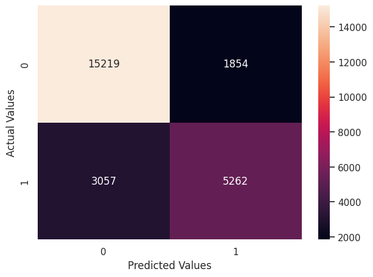

```python
cm = confusion_matrix(y_train, pred_train9)
plt.figure(figsize=(7, 5))
sns.heatmap(cm, annot=True, fmt="g")
plt.xlabel("Predicted Values")
plt.ylabel("Actual Values")
plt.show()
```

```python
#Accuracy on train set9
print("Accuracy on training set : ", accuracy_score(y_train, pred_train9))
```

```
Accuracy on training set :  0.8065926275992439
```

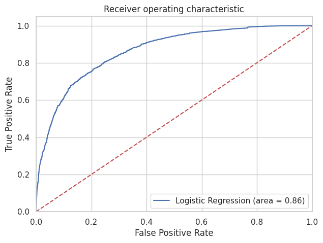

```python
logit_roc_auc_train = roc_auc_score(y_train, lg9.predict(X_train9))
fpr, tpr, thresholds = roc_curve(y_train, lg9.predict(X_train9))
plt.figure(figsize=(7, 5))
plt.plot(fpr, tpr, label="Logistic Regression (area = %0.2f)" % logit_roc_auc_train)
plt.plot([0, 1], [0, 1], "r--")
plt.xlim([0.0, 1.0])
plt.ylim([0.0, 1.05])
plt.xlabel("False Positive Rate")
plt.ylabel("True Positive Rate")
plt.title("Receiver operating characteristic")
plt.legend(loc="lower right")
plt.show()
```

Model is performing well on the training set

```python
# Drop features from test data
X_test = X_test.drop(["arrival_date", "no_of_adults", "no_of_children", "room_type_reserved_Room_Type 3", "market_segment_type_Online", "market_segment_type_Complementary", "no_of_previous_bookings_not_canceled", "type_of_meal_plan_Meal Plan 3",], axis=1)
```

```python
#Print features of xtrain9 and xtest
print(X_train9.columns)
print(X_test.columns)
```

```
Index(['const', 'no_of_weekend_nights', 'no_of_week_nights',
       'required_car_parking_space', 'lead_time', 'arrival_year',
       'arrival_month', 'repeated_guest', 'no_of_previous_cancellations',
       'avg_price_per_room', 'no_of_special_requests',
       'type_of_meal_plan_Meal Plan 2', 'type_of_meal_plan_Not Selected',
       'room_type_reserved_Room_Type 2', 'room_type_reserved_Room_Type 4',
       'room_type_reserved_Room_Type 5', 'room_type_reserved_Room_Type 6',
       'room_type_reserved_Room_Type 7', 'market_segment_type_Corporate',
       'market_segment_type_Offline'],
      dtype='object')
Index(['const', 'no_of_weekend_nights', 'no_of_week_nights',
       'required_car_parking_space', 'lead_time', 'arrival_year',
       'arrival_month', 'repeated_guest', 'no_of_previous_cancellations',
       'avg_price_per_room', 'no_of_special_requests',
       'type_of_meal_plan_Meal Plan 2', 'type_of_meal_plan_Not Selected',
       'room_type_reserved_Room_Type 2', 'room_type_reserved_Room_Type 4',
       'room_type_reserved_Room_Type 5', 'room_type_reserved_Room_Type 6',
       'room_type_reserved_Room_Type 7', 'market_segment_type_Corporate',
       'market_segment_type_Offline'],
      dtype='object')
```

```python
# Convert all columns in X_test to numeric types
X_test = X_test.apply(pd.to_numeric, errors='coerce')

# Handle missing values (e.g., fill with 0 or mean)
X_test.fillna(0, inplace=True)

# Ensure column order matches X_train9
X_test = X_test[X_train9.columns]

# Convert all columns to float64
X_test = X_test.astype(np.float64) #This ensures all features are of the correct datatype

pred_test = lg9.predict(X_test) > 0.5
pred_test = np.round(pred_test)
```

```python
print("Accuracy on training set : ", accuracy_score(y_train, pred_train9))
print("Accuracy on test set : ", accuracy_score(y_test, pred_test))
```

```
Accuracy on training set :  0.8065926275992439
Accuracy on test set :  0.802719838279886
```

The accuracy on the test set (80.3% is almost the same as the training set (80.6%).

Function for model performance

```python
# defining a function to compute different metrics to check performance of a classification model built using statsmodels

from sklearn.metrics import accuracy_score, recall_score, precision_score, f1_score
import pandas as pd
import numpy as np

def model_performance_classification_statsmodels(
    model, predictors, target, threshold=0.5
):
    """
    Function to compute different metrics to check classification model performance

    model: classifier
    predictors: independent variables
    target: dependent variable
    threshold: threshold for classifying the observation as class 1
    """

    # checking which probabilities are greater than threshold
    pred_temp = model.predict(predictors) > threshold
    # rounding off the above values to get classes
    pred = np.round(pred_temp)

    acc = accuracy_score(target, pred)  # to compute Accuracy
    recall = recall_score(target, pred)  # to compute Recall
    precision = precision_score(target, pred)  # to compute Precision
    f1 = f1_score(target, pred)  # to compute F1-score

    # creating a dataframe of metrics
    df_perf = pd.DataFrame(
        {"Accuracy": acc, "Recall": recall, "Precision": precision, "F1": f1,},
        index=[0],
    )

    return df_perf
```

```python
print("Training performance:")
model_performance_classification_statsmodels(lg9, X_train9, y_train)
```

```
Training performance:
```

|  | Accuracy | Recall | Precision | F1 |
| --- | --- | --- | --- | --- |
| 0 | 0.806593 | 0.632528 | 0.73946 | 0.681827 |

Now, we will adjust the classification threshold to find the best for our data.

```python
# Optimal threshold per AUC-ROC curve
# The optimal cut off would be where tpr is high and fpr is low
fpr, tpr, thresholds = roc_curve(y_train, lg9.predict(X_train9))

optimal_idx = np.argmax(tpr - fpr)
optimal_threshold_auc_roc = thresholds[optimal_idx]
print(optimal_threshold_auc_roc)
```

```
0.3329571917391589
```

```python
#Adjust classification threshold for lg9 to 0.33
pred_test_adj = lg9.predict(X_test) > 0.33
pred_test_adj = np.round(pred_test_adj)
```

```python
# checking model performance for this model
log_reg_model_train_perf_threshold_auc_roc = model_performance_classification_statsmodels(
    lg9, X_train9, y_train, threshold=optimal_threshold_auc_roc
)
print("Training performance:")
log_reg_model_train_perf_threshold_auc_roc
```

```
Training performance:
```

|  | Accuracy | Recall | Precision | F1 |
| --- | --- | --- | --- | --- |
| 0 | 0.784342 | 0.766078 | 0.643542 | 0.699484 |

Find new threshold using the intersection of the recall and precision curves

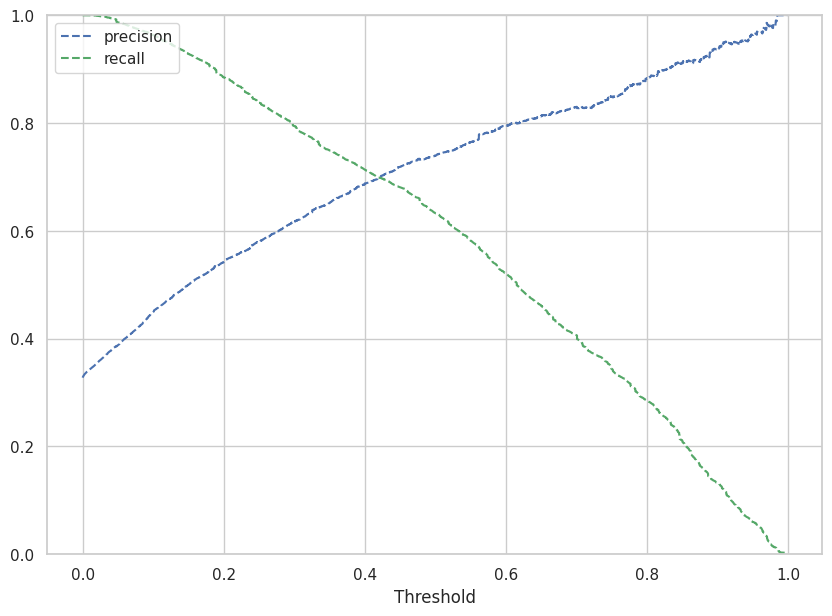

```python
y_scores = lg9.predict(X_train9)
prec, rec, tre = precision_recall_curve(y_train, y_scores,)


def plot_prec_recall_vs_tresh(precisions, recalls, thresholds):
    plt.plot(thresholds, precisions[:-1], "b--", label="precision")
    plt.plot(thresholds, recalls[:-1], "g--", label="recall")
    plt.xlabel("Threshold")
    plt.legend(loc="upper left")
    plt.ylim([0, 1])


plt.figure(figsize=(10, 7))
plot_prec_recall_vs_tresh(prec, rec, tre)
plt.show()
```

```python
#Adjust classification threshold for lg9 to 0.42 and create a new name for the model
lg9_adj = lg9
lg9_adj.threshold = 0.42
pred_test_adj = lg9.predict(X_test) > 0.42
pred_test_adj = np.round(pred_test_adj)
```

```python
# checking model performance for this model
log_reg_model_train_perf_threshold_auc_roc = model_performance_classification_statsmodels(
    lg9_adj, X_train9, y_train, threshold=0.42
)
print("Training performance:")
log_reg_model_train_perf_threshold_auc_roc
```

```
Training performance:
```

|  | Accuracy | Recall | Precision | F1 |
| --- | --- | --- | --- | --- |
| 0 | 0.802654 | 0.698642 | 0.698894 | 0.698768 |

This adjusted model (threshold at 0.42) is the best balance of precision and recall, while maintaining a good accuracy of 80.2%

## Final Model Summary

```python
#Final summary of lg9_adj
print(lg9_adj.summary())
```

```
                           Logit Regression Results
==============================================================================
Dep. Variable:         booking_status   No. Observations:                25392
Model:                          Logit   Df Residuals:                    25372
Method:                           MLE   Df Model:                           19
Date:                Thu, 26 Sep 2024   Pseudo R-squ.:                  0.3312
Time:                        23:19:27   Log-Likelihood:                -10741.
converged:                       True   LL-Null:                       -16060.
Covariance Type:            nonrobust   LLR p-value:                     0.000
==================================================================================================
                                     coef    std err          z      P>|z|      [0.025      0.975]
--------------------------------------------------------------------------------------------------
const                           -869.8889    120.911     -7.194      0.000   -1106.870    -632.908
no_of_weekend_nights               0.1498      0.020      7.568      0.000       0.111       0.189
no_of_week_nights                  0.0362      0.012      2.953      0.003       0.012       0.060
required_car_parking_space        -1.6148      0.137    -11.780      0.000      -1.883      -1.346
lead_time                          0.0159      0.000     59.908      0.000       0.015       0.016
arrival_year                       0.4298      0.060      7.172      0.000       0.312       0.547
arrival_month                     -0.0492      0.006     -7.595      0.000      -0.062      -0.036
repeated_guest                    -3.0747      0.597     -5.152      0.000      -4.244      -1.905
no_of_previous_cancellations       0.2892      0.078      3.722      0.000       0.137       0.441
avg_price_per_room                 0.0190      0.001     26.645      0.000       0.018       0.020
no_of_special_requests            -1.4855      0.030    -49.272      0.000      -1.545      -1.426
type_of_meal_plan_Meal Plan 2      0.1669      0.067      2.492      0.013       0.036       0.298
type_of_meal_plan_Not Selected     0.2098      0.053      3.974      0.000       0.106       0.313
room_type_reserved_Room_Type 2    -0.3734      0.129     -2.891      0.004      -0.627      -0.120
room_type_reserved_Room_Type 4    -0.2678      0.052     -5.189      0.000      -0.369      -0.167
room_type_reserved_Room_Type 5    -0.6879      0.214     -3.211      0.001      -1.108      -0.268
room_type_reserved_Room_Type 6    -0.7419      0.120     -6.186      0.000      -0.977      -0.507
room_type_reserved_Room_Type 7    -1.3150      0.292     -4.504      0.000      -1.887      -0.743
market_segment_type_Corporate     -0.8710      0.103     -8.445      0.000      -1.073      -0.669
market_segment_type_Offline       -1.7725      0.052    -34.288      0.000      -1.874      -1.671
==================================================================================================
```

```python
# checking model performance for this model
log_reg_model_train_perf_threshold_auc_roc = model_performance_classification_statsmodels(
    lg9_adj, X_test, y_test, threshold=0.42
)
print("Training performance:")
log_reg_model_train_perf_threshold_auc_roc
```

```
Training performance:
```

|  | Accuracy | Recall | Precision | F1 |
| --- | --- | --- | --- | --- |
| 0 | 0.796563 | 0.694055 | 0.687882 | 0.690955 |

The final model lg9_adj performed with similar results on the test data as it did on the training data.

## Building a Decision Tree model

```python
#Create a copy of data and call it dt
dt = data_hotel.copy()
#Drop booking id from dt
dt = dt.drop(["Booking_ID"], axis=1)
#Show dt head
dt.head()
```

|  | no_of_adults | no_of_children | no_of_weekend_nights | no_of_week_nights | type_of_meal_plan | required_car_parking_space | room_type_reserved | lead_time | arrival_year | arrival_month | arrival_date | market_segment_type | repeated_guest | no_of_previous_cancellations | no_of_previous_bookings_not_canceled | avg_price_per_room | no_of_special_requests | booking_status |
| --- | --- | --- | --- | --- | --- | --- | --- | --- | --- | --- | --- | --- | --- | --- | --- | --- | --- | --- |
| 0 | 2 | 0 | 1 | 2 | Meal Plan 1 | 0 | Room_Type 1 | 224 | 2017 | 10 | 2 | Offline | 0 | 0 | 0 | 65.00 | 0 | Not_Canceled |
| 1 | 2 | 0 | 2 | 3 | Not Selected | 0 | Room_Type 1 | 5 | 2018 | 11 | 6 | Online | 0 | 0 | 0 | 106.68 | 1 | Not_Canceled |
| 2 | 1 | 0 | 2 | 1 | Meal Plan 1 | 0 | Room_Type 1 | 1 | 2018 | 2 | 28 | Online | 0 | 0 | 0 | 60.00 | 0 | Canceled |
| 3 | 2 | 0 | 0 | 2 | Meal Plan 1 | 0 | Room_Type 1 | 211 | 2018 | 5 | 20 | Online | 0 | 0 | 0 | 100.00 | 0 | Canceled |
| 4 | 2 | 0 | 1 | 1 | Not Selected | 0 | Room_Type 1 | 48 | 2018 | 4 | 11 | Online | 0 | 0 | 0 | 94.50 | 0 | Canceled |

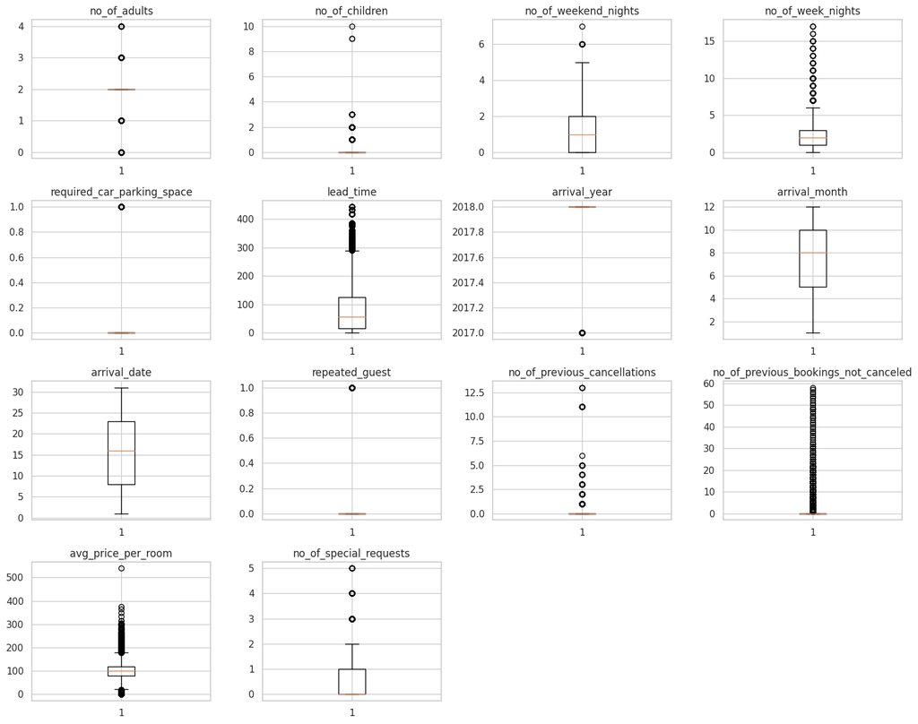

```python
# outlier detection using boxplot
numeric_columns = dt.select_dtypes(include=np.number).columns.tolist()

plt.figure(figsize=(15, 12))

for i, variable in enumerate(numeric_columns):
    plt.subplot(4, 4, i + 1)
    plt.boxplot(dt[variable], whis=1.5)
    plt.tight_layout()
    plt.title(variable)

plt.show()
```

There are outliers in the data. We will not treat them as they are proper values (as we decided before with logistic regression model)

```python
#Change booking status in dt to numerical variable
dt["booking_status"] = dt["booking_status"].map({"Not_Canceled": 0, "Canceled": 1})
```

```python
dt.info()
```

```
<class 'pandas.core.frame.DataFrame'>
RangeIndex: 36275 entries, 0 to 36274
Data columns (total 18 columns):
 #   Column                                Non-Null Count  Dtype
---  ------                                --------------  -----
 0   no_of_adults                          36275 non-null  int64
 1   no_of_children                        36275 non-null  int64
 2   no_of_weekend_nights                  36275 non-null  int64
 3   no_of_week_nights                     36275 non-null  int64
 4   type_of_meal_plan                     36275 non-null  object
 5   required_car_parking_space            36275 non-null  int64
 6   room_type_reserved                    36275 non-null  object
 7   lead_time                             36275 non-null  int64
 8   arrival_year                          36275 non-null  int64
 9   arrival_month                         36275 non-null  int64
 10  arrival_date                          36275 non-null  int64
 11  market_segment_type                   36275 non-null  object
 12  repeated_guest                        36275 non-null  int64
 13  no_of_previous_cancellations          36275 non-null  int64
 14  no_of_previous_bookings_not_canceled  36275 non-null  int64
 15  avg_price_per_room                    36275 non-null  float64
 16  no_of_special_requests                36275 non-null  int64
 17  booking_status                        36275 non-null  int64
dtypes: float64(1), int64(14), object(3)
memory usage: 5.0+ MB
```

```python
X = dt.drop(["booking_status"], axis=1)
Y = dt["booking_status"]

X = pd.get_dummies(X, drop_first=True)

# Splitting data in train and test sets
X_train, X_test, y_train, y_test = train_test_split(
    X, Y, test_size=0.30, random_state=1
)
```

```python
print("Shape of Training set : ", X_train.shape)
print("Shape of test set : ", X_test.shape)
print("Percentage of classes in training set:")
print(y_train.value_counts(normalize=True))
print("Percentage of classes in test set:")
print(y_test.value_counts(normalize=True))
```

```
Shape of Training set :  (25392, 27)
Shape of test set :  (10883, 27)
Percentage of classes in training set:
booking_status
0    0.670644
1    0.329356
Name: proportion, dtype: float64
Percentage of classes in test set:
booking_status
0    0.676376
1    0.323624
Name: proportion, dtype: float64
```

## Decision Tree Model

```python
# To build model for prediction
from sklearn.tree import DecisionTreeClassifier
from sklearn import tree

# To tune different models
from sklearn.model_selection import GridSearchCV

# To get diferent metric scores
from sklearn.metrics import (
    f1_score,
    accuracy_score,
    recall_score,
    precision_score,
    confusion_matrix,
    make_scorer,)
```

```python
model0 = DecisionTreeClassifier(random_state=1)
model0.fit(X_train, y_train)
```

```
DecisionTreeClassifier(random_state=1)
```

```python
# defining a function to compute different metrics to check performance of a classification model built using sklearn
def model_performance_classification_sklearn(model, predictors, target):
    """
    Function to compute different metrics to check classification model performance

    model: classifier
    predictors: independent variables
    target: dependent variable
    """

    # predicting using the independent variables
    pred = model.predict(predictors)

    acc = accuracy_score(target, pred)  # to compute Accuracy
    recall = recall_score(target, pred)  # to compute Recall
    precision = precision_score(target, pred)  # to compute Precision
    f1 = f1_score(target, pred)  # to compute F1-score

    # creating a dataframe of metrics
    df_perf = pd.DataFrame(
        {"Accuracy": acc, "Recall": recall, "Precision": precision, "F1": f1,},
        index=[0],
    )

    return df_perf
```

```python
def confusion_matrix_sklearn(model, predictors, target):
    """
    To plot the confusion_matrix with percentages

    model: classifier
    predictors: independent variables
    target: dependent variable
    """
    y_pred = model.predict(predictors)
    cm = confusion_matrix(target, y_pred)
    labels = np.asarray(
        [
            ["{0:0.0f}".format(item) + "\n{0:.2%}".format(item / cm.flatten().sum())]
            for item in cm.flatten()
        ]
    ).reshape(2, 2)

    plt.figure(figsize=(6, 4))
    sns.heatmap(cm, annot=labels, fmt="")
    plt.ylabel("True label")
    plt.xlabel("Predicted label")
```

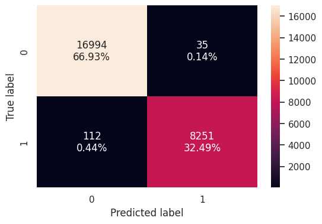

```python
confusion_matrix_sklearn(model0, X_train, y_train)
```

```python
decision_tree_perf_train_without = model_performance_classification_sklearn(
    model0, X_train, y_train
)
decision_tree_perf_train_without
```

|  | Accuracy | Recall | Precision | F1 |
| --- | --- | --- | --- | --- |
| 0 | 0.994211 | 0.986608 | 0.995776 | 0.991171 |

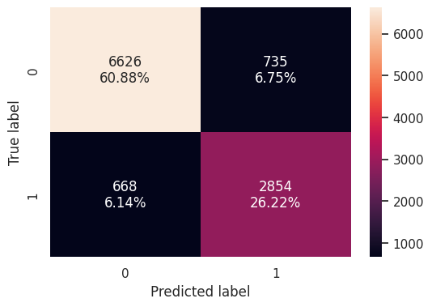

```python
confusion_matrix_sklearn(model0, X_test, y_test)
```

```python
decision_tree_perf_test_without = model_performance_classification_sklearn(
    model0, X_test, y_test
)
decision_tree_perf_test_without
```

|  | Accuracy | Recall | Precision | F1 |
| --- | --- | --- | --- | --- |
| 0 | 0.871083 | 0.810335 | 0.795208 | 0.8027 |

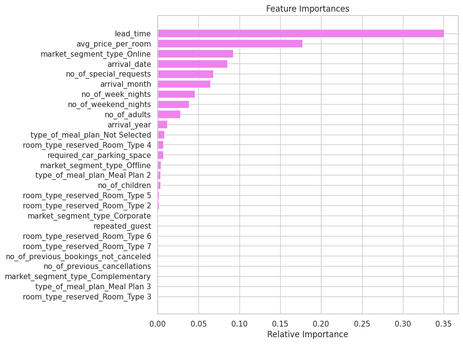

```python
feature_names = list(X_train.columns)
importances = model0.feature_importances_
indices = np.argsort(importances)

plt.figure(figsize=(8, 8))
plt.title("Feature Importances")
plt.barh(range(len(indices)), importances[indices], color="violet", align="center")
plt.yticks(range(len(indices)), [feature_names[i] for i in indices])
plt.xlabel("Relative Importance")
plt.show()
```